# Eco 602 Final Project

## `par() and mfrow=`

The function `par()` with the argument `mfrow=` can be used to plot more than one graph at a time!

- This can be useful to combine more than one graph
- `mfrow=` uses a vector:

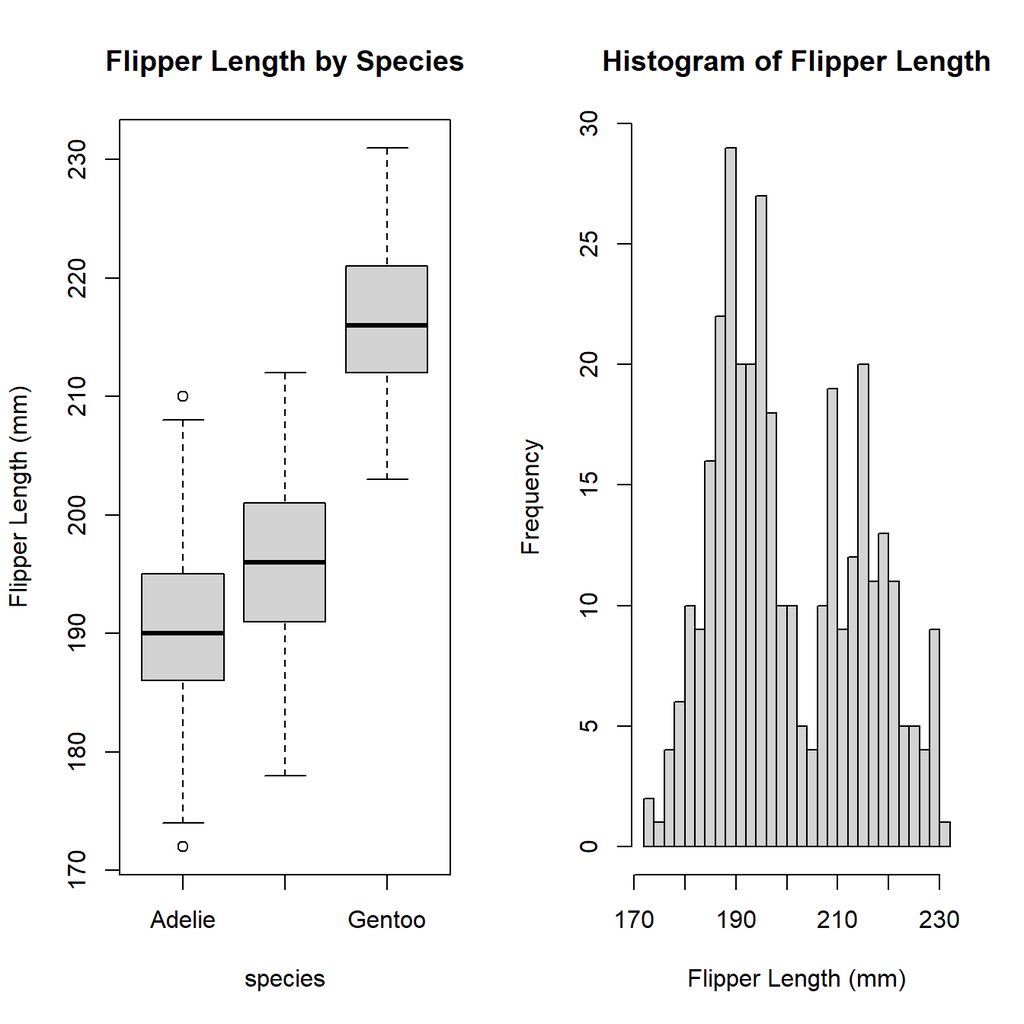

```r
## this is how to implement the par() function:

par(mfrow = c(1,2)) ##mfrow describes the layout. Here, 1X2
## The graphs following par() will be plotted together
boxplot(flipper_length_mm ~ species, data = penguins,
        main = "Flipper Length by Species",
        ylab = "Flipper Length (mm)")
hist(penguins$flipper_length_mm,
     breaks = 40,
     main = "Histogram of Flipper Length",
     xlab = "Flipper Length (mm)")
```

# Functions 4: Distribution Functions

## `dnorm()`

The function `dnorm()` can be used to calculate the probability density of a normal distribution!

- For example:

```r
## The following will return the height of the curve of the normal distribution
## at X = 12
## for a normal distribution where the mean is 18 and the standard deviation is 6:

dnorm(12, mean = 18, sd = 6)
```

```
## [1] 0.04032845
```

## `pnorm()`

The function `pnorm()` returns the cumulative density for a normal distribution!

- `pnorm()` gives me the value of the probability of observing `x` or *less*

```r
## What is the probability of observing a value less than 15 in a normal distribution with a mean of 18 and a standard deviation of 6

pnorm(15, mean = 18, sd = 6)
```

```
## [1] 0.3085375
```

In this case we return 30.85% probability!

## `qnorm()`

The function `qnorm()` returns the value at a quantile of a normal distribution!

- `qnorm()` gives me the value at the specified percentile, `p`
- percentile argument must be given as a decimal

```r
## What is the value at the 31% percentile for a standard distribution with a mean of 18 and a standard deviation of 6?

qnorm(0.31, mean = 18, sd = 6)
```

```
## [1] 15.0249
```

Here, we return something close to 15.

## `dbinom()`

Similar to `dnorm()`, the function `dbinom()` returns probability, but returns it for a binomial distribution. In a binomial distribution, we call it probability mass instead of density.

- `dbinom()` will give us the probability of observing a value (x) in a binomial distribution:

```r
## what is the probability of observing 5 successes (x), in a binomial distribution with twenty trials (size) and a success rate of 25% (prob)

dbinom(5, size = 20, prob = .25)
```

```
## [1] 0.2023312
```

Here we get an answer close to 20%

## `qbinom()`

`qbinom()` is a function that give us the quantile of a binomial distribution

- We can use `qbinom()` to return the value at a quantile of a binomial distribution:

```r
## what is the 20th quantile of a binomial distribution with a size of 20 and a probability of 25%?

qbinom(.20, size = 20, prob = .25)
```

```
## [1] 3
```

And the answer is 3.

# Functions 5: Other Functions

## `subset()`

The function `subset()` can be used to isolate data from a data frame.

```r
## import penguins data
require(palmerpenguins)

## summarize the data to look for something to subset:
summary(penguins)
```

```
##       species          island    bill_length_mm  bill_depth_mm
##  Adelie   :152   Biscoe   :168   Min.   :32.10   Min.   :13.10
##  Chinstrap: 68   Dream    :124   1st Qu.:39.23   1st Qu.:15.60
##  Gentoo   :124   Torgersen: 52   Median :44.45   Median :17.30
##                                  Mean   :43.92   Mean   :17.15
##                                  3rd Qu.:48.50   3rd Qu.:18.70
##                                  Max.   :59.60   Max.   :21.50
##                                  NA's   :2       NA's   :2
##  flipper_length_mm  body_mass_g       sex           year
##  Min.   :172.0     Min.   :2700   female:165   Min.   :2007
##  1st Qu.:190.0     1st Qu.:3550   male  :168   1st Qu.:2007
##  Median :197.0     Median :4050   NA's  : 11   Median :2008
##  Mean   :200.9     Mean   :4202                Mean   :2008
##  3rd Qu.:213.0     3rd Qu.:4750                3rd Qu.:2009
##  Max.   :231.0     Max.   :6300                Max.   :2009
##  NA's   :2         NA's   :2
```

```r
## create a subset!
dat_adelie <- subset(penguins, species == "Adelie")

## test the subset
head(dat_adelie)
```

```
## # A tibble: 6 x 8
##   species island bill_length_mm bill_depth_mm flipper_length_~ body_mass_g sex
##   <fct>   <fct>           <dbl>         <dbl>            <int>       <int> <fct>
## 1 Adelie  Torge~           39.1          18.7              181        3750 male
## 2 Adelie  Torge~           39.5          17.4              186        3800 fema~
## 3 Adelie  Torge~           40.3          18                195        3250 fema~
## 4 Adelie  Torge~           NA            NA                 NA          NA <NA>
## 5 Adelie  Torge~           36.7          19.3              193        3450 fema~
## 6 Adelie  Torge~           39.3          20.6              190        3650 male
## # ... with 1 more variable: year <int>
```

Here we have subsetted the penguin data into just one species, Adelie.

## `library() and require()`

The `library()` and `require()` functions can be used to import pre-installed code and datasets that come with R. These are called packages.

- The first time you access a package, you should use `install.packages()` to bring it in to R
- They can be used interchangeably but `require()` is necessary for use inside of a function

```r
## Using library() to load a package of code that we need:
library(stats)

## This is the package that we have been using for our distribution functions. Here we can see a description:
packageDescription("stats")
```

```
## Package: stats
## Version: 4.0.2
## Priority: base
## Title: The R Stats Package
## Author: R Core Team and contributors worldwide
## Maintainer: R Core Team <R-core@r-project.org>
## Description: R statistical functions.
## License: Part of R 4.0.2
## Imports: utils, grDevices, graphics
## Suggests: MASS, Matrix, SuppDists, methods, stats4
## NeedsCompilation: yes
## Built: R 4.0.2; x86_64-w64-mingw32; 2020-06-22 08:44:20 UTC; windows
##
## -- File: C:/Program Files/R/R-4.0.2/library/stats/Meta/package.rds
```

```r
## another package that we have been relying heavily upon is the palmer penguins data package
library(palmerpenguins)

## this package has supplied us with our penguin data
packageDescription("palmerpenguins")
```

```
## Package: palmerpenguins
## Title: Palmer Archipelago (Antarctica) Penguin Data
## Version: 0.1.0
## Date: 2020-07-11
## Authors@R: c( person(given = "Allison", family = "Horst", role =
##         c("aut", "cre"), email = "ahorst@ucsb.edu", comment = c(ORCID =
##         "0000-0002-6047-5564")), person(given = "Alison", family =
##         "Hill", role = c("aut"), email = "apresstats@gmail.com",
##         comment = c(ORCID = "0000-0002-8082-1890")), person(given =
##         "Kristen", family = "Gorman", role = c("aut"), email =
##         "kbgorman@alaska.edu", comment = c(ORCID =
##         "0000-0002-0258-9264")) )
## Description: Size measurements, clutch observations, and blood isotope
##         ratios for adult foraging Adélie, Chinstrap, and Gentoo
##         penguins observed on islands in the Palmer Archipelago near
##         Palmer Station, Antarctica. Data were collected and made
##         available by Dr. Kristen Gorman and the Palmer Station Long
##         Term Ecological Research (LTER) Program.
## License: CC0
## Encoding: UTF-8
## LazyData: true
## RoxygenNote: 7.1.1
## Depends: R (>= 2.10)
## Suggests: knitr, rmarkdown, tibble, ggplot2, dplyr, tidyr, recipes
## URL: https://allisonhorst.github.io/palmerpenguins/,
##         https://github.com/allisonhorst/palmerpenguins
## BugReports: https://github.com/allisonhorst/palmerpenguins/issues
## NeedsCompilation: no
## Packaged: 2020-07-16 21:52:10 UTC; ahorst
## Author: Allison Horst [aut, cre]
##         (<https://orcid.org/0000-0002-6047-5564>), Alison Hill [aut]
##         (<https://orcid.org/0000-0002-8082-1890>), Kristen Gorman [aut]
##         (<https://orcid.org/0000-0002-0258-9264>)
## Maintainer: Allison Horst <ahorst@ucsb.edu>
## Repository: CRAN
## Date/Publication: 2020-07-23 15:20:05 UTC
## Built: R 4.0.2; ; 2020-09-05 03:09:28 UTC; windows
##
## -- File: C:/Users/Michelle/Documents/R/win-library/4.0/palmerpenguins/Meta/package.rds
```

## `read.csv()`

The function `read.csv()` is used to import data from a local csv file:

```r
### Import data using read.csv function

dat_delomys <- read.csv("data/delomys.csv")

## Test the import
summary(dat_delomys)
```

```
##        X            genus             binomial           body_mass
##  Min.   :27526   Length:1585        Length:1585        Min.   :  5.00
##  1st Qu.:27950   Class :character   Class :character   1st Qu.: 35.00
##  Median :28348   Mode  :character   Mode  :character   Median : 43.00
##  Mean   :28371                                         Mean   : 44.06
##  3rd Qu.:28790                                         3rd Qu.: 54.00
##  Max.   :35552                                         Max.   :105.00
##   body_length        age                sex              longitude
##  Min.   : 49.0   Length:1585        Length:1585        Min.   :-49681671
##  1st Qu.:106.0   Class :character   Class :character   1st Qu.:      -50
##  Median :116.0   Mode  :character   Mode  :character   Median :      -50
##  Mean   :114.7                                         Mean   :   -62739
##  3rd Qu.:124.0                                         3rd Qu.:      -47
##  Max.   :265.0                                         Max.   :      -41
##     latitude            status
##  Min.   :-22383667   Length:1585
##  1st Qu.:      -29   Class :character
##  Median :      -29   Mode  :character
##  Mean   :   -28272
##  3rd Qu.:      -24
##  Max.   :      -20
```

Using `summary()`, we can see that the data did indeed import.

# Part 2: Data Anaylsis

Now that it is imported, we will preform a data analysis on the Delomys data.

## Numerical Exploration

We will start with a numerical exploration:

### Summary of `dat_delomys`:

```
##        X            genus             binomial           body_mass
##  Min.   :27526   Length:1585        Length:1585        Min.   :  5.00
##  1st Qu.:27950   Class :character   Class :character   1st Qu.: 35.00
##  Median :28348   Mode  :character   Mode  :character   Median : 43.00
##  Mean   :28371                                         Mean   : 44.06
##  3rd Qu.:28790                                         3rd Qu.: 54.00
##  Max.   :35552                                         Max.   :105.00
##   body_length        age                sex              longitude
##  Min.   : 49.0   Length:1585        Length:1585        Min.   :-49681671
##  1st Qu.:106.0   Class :character   Class :character   1st Qu.:      -50
##  Median :116.0   Mode  :character   Mode  :character   Median :      -50
##  Mean   :114.7                                         Mean   :   -62739
##  3rd Qu.:124.0                                         3rd Qu.:      -47
##  Max.   :265.0                                         Max.   :      -41
##     latitude            status
##  Min.   :-22383667   Length:1585
##  1st Qu.:      -29   Class :character
##  Median :      -29   Mode  :character
##  Mean   :   -28272
##  3rd Qu.:      -24
##  Max.   :      -20
```

### Shapiro Tests

```
##
##  Shapiro-Wilk normality test
##
## data:  dat_delomys$body_mass
## W = 0.99506, p-value = 4.33e-05
```

```
##
##  Shapiro-Wilk normality test
##
## data:  dat_delomys$body_length
## W = 0.87609, p-value < 2.2e-16
```

Since both of these return a p-value that is much lower than .05, we know that our variables are not normally distributed.

## Graphical Exploration

### Scatterplot

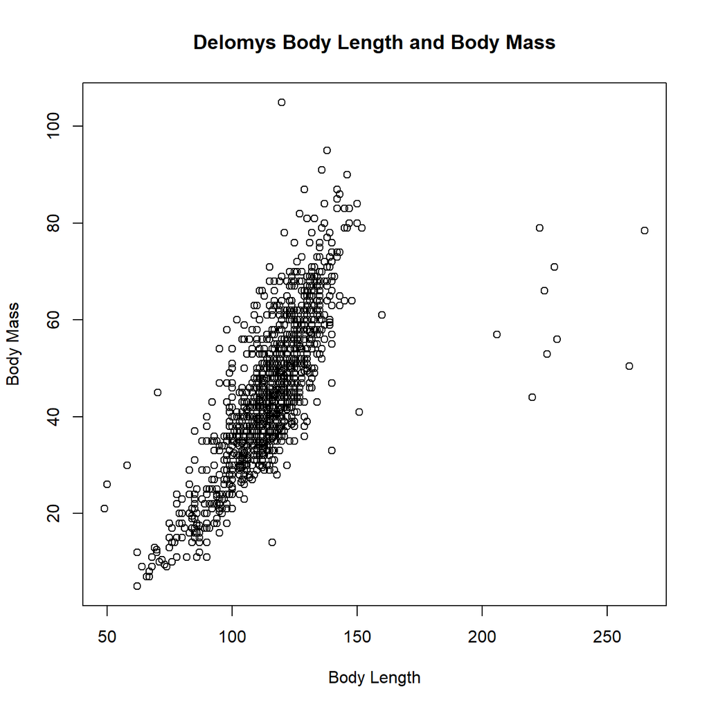

### Histograms

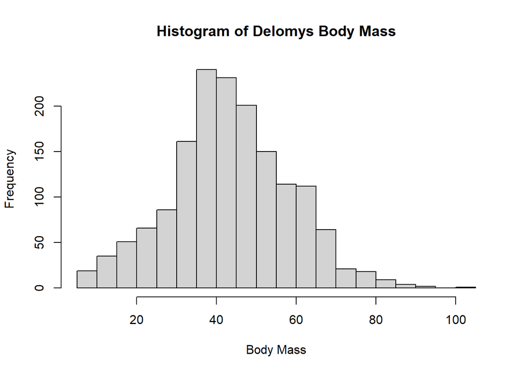

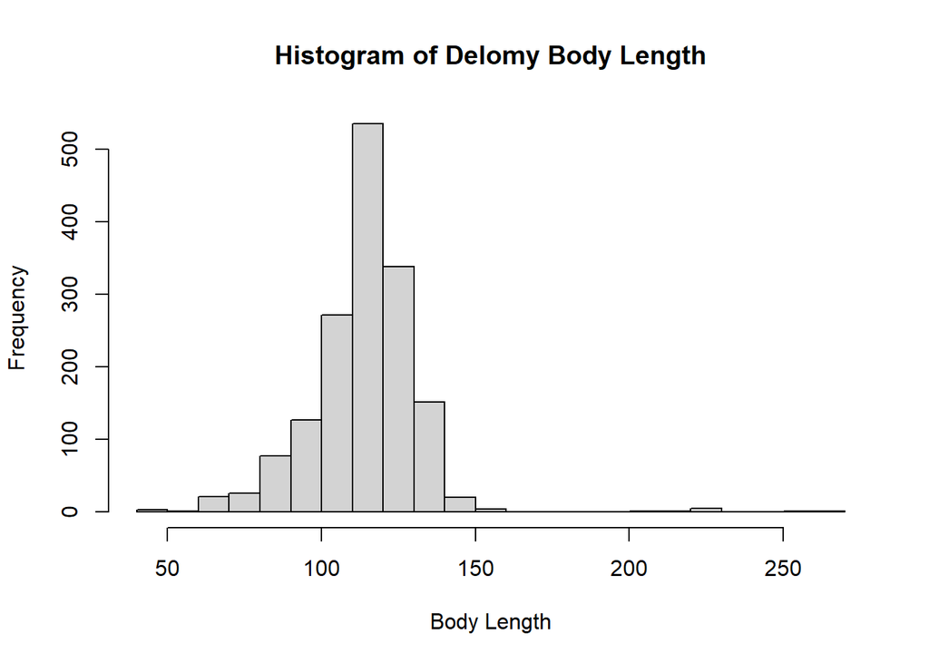

### Boxplots

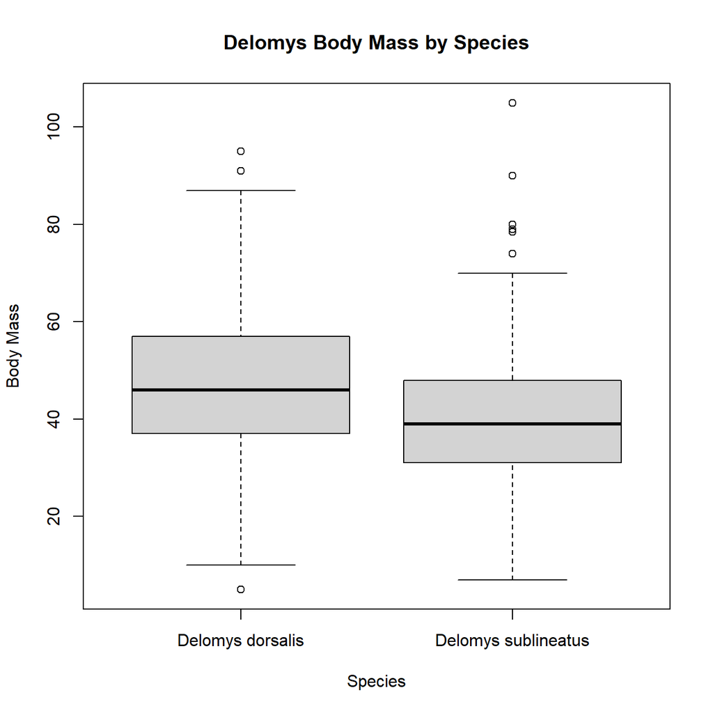

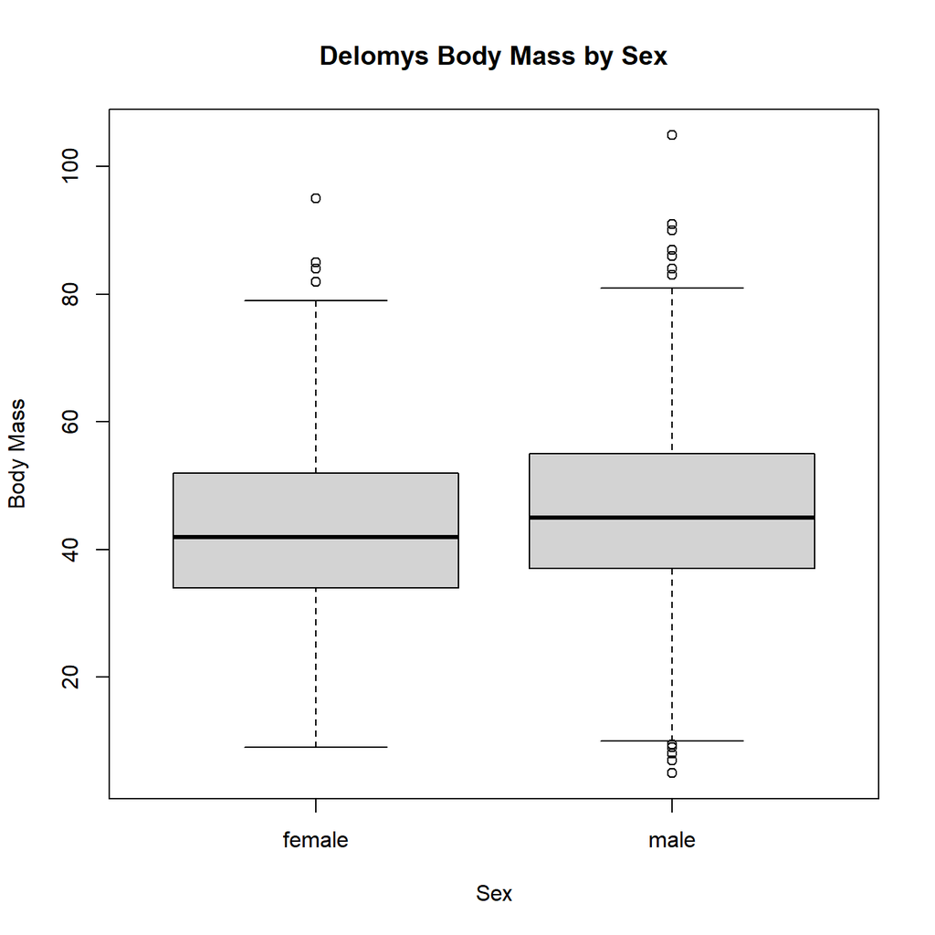

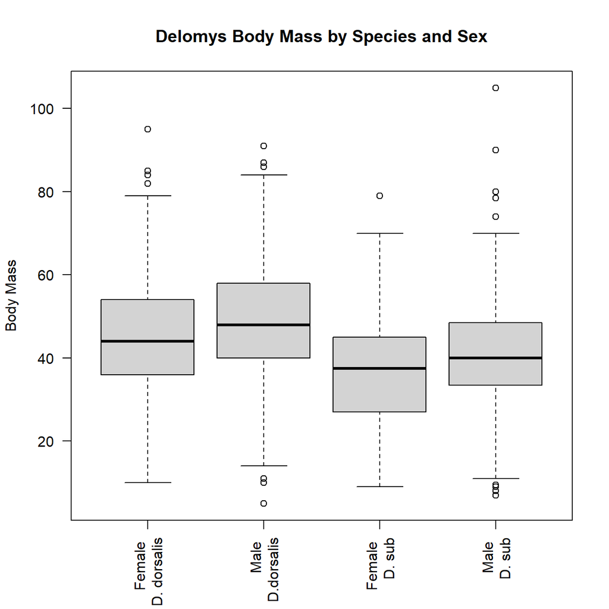

## Model Building

Now we construct the models:

```r
fit1 <- lm(body_length ~ body_mass, data = dat_delomys) ## simple linear regression
fit2 <- lm(body_mass ~ sex, data = dat_delomys)   ## 1-way ANOVA
fit3 <- lm(body_mass ~ binomial, data = dat_delomys)  ## 1-way ANOVA
fit4 <- lm(body_mass ~ sex + binomial, data = dat_delomys) ## 2-way additive ANOVA
fit5 <- lm(body_mass ~ sex*binomial, data = dat_delomys) ## 2-way factorial ANOVA
```

## Model Diagnostics

### Visual Diagnostic

Here we use histograms of the residuals as a visual diagnostic:

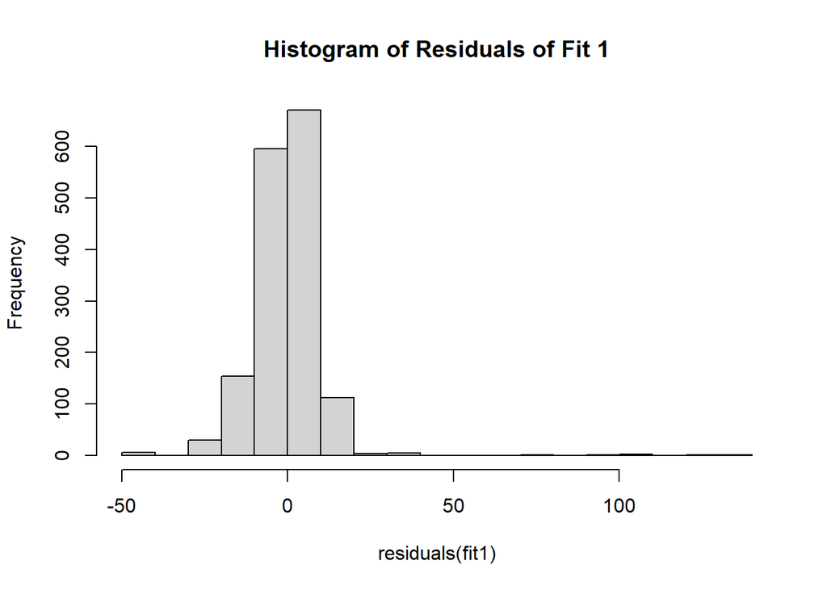

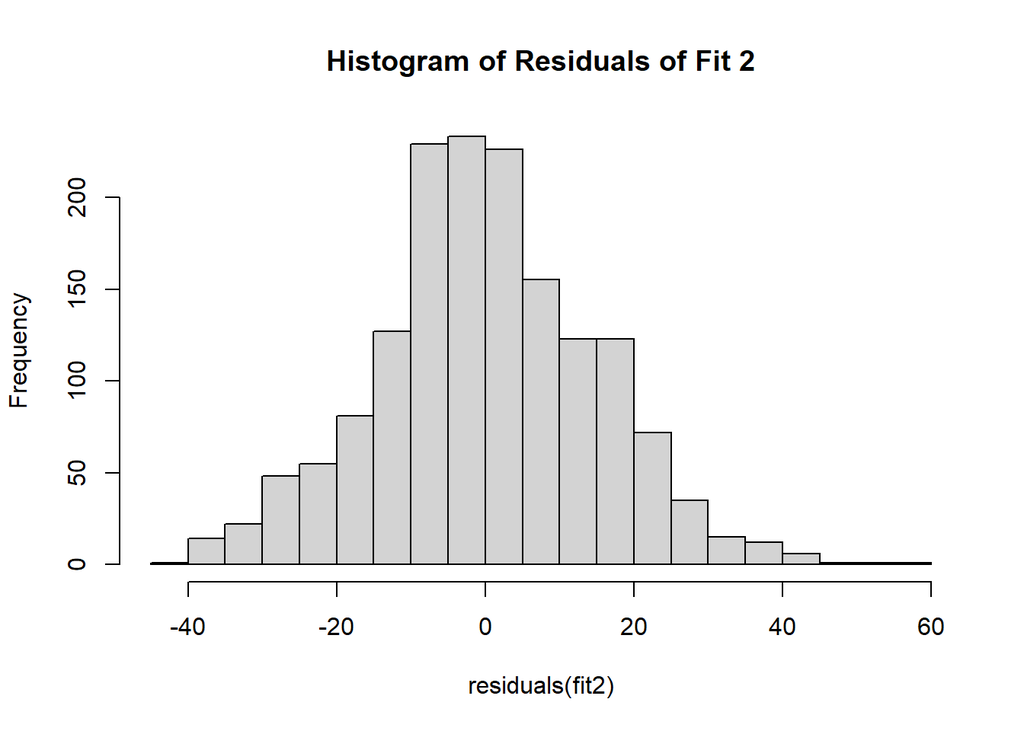

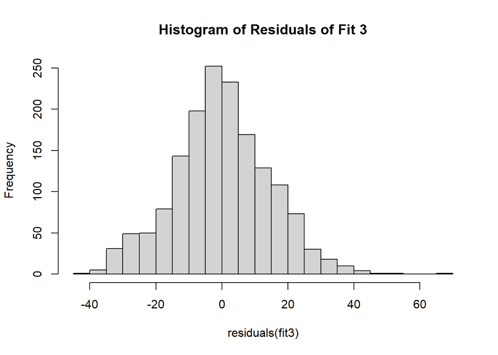

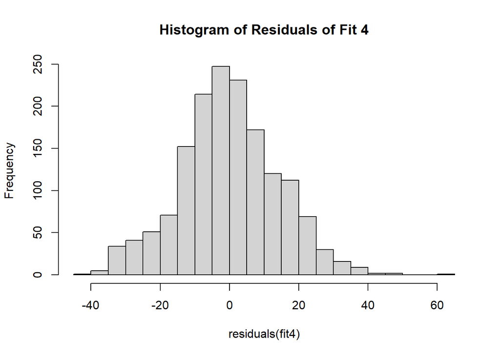

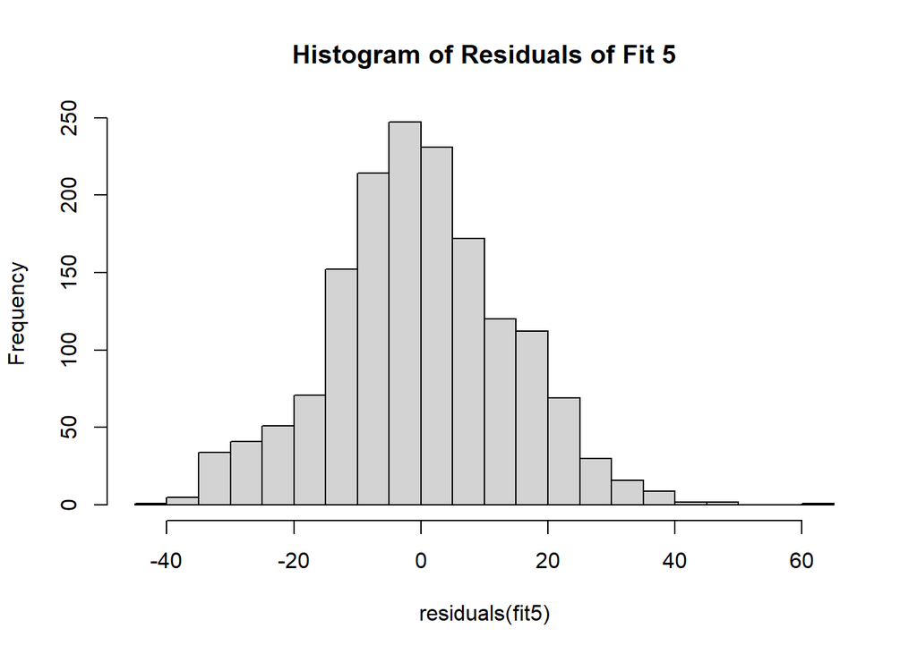

### Numerical Diagnostic

Here we use the Shapiro-Wilk test on the residuals of our models as a numerical diagnostic:

```
##
##  Shapiro-Wilk normality test
##
## data:  residuals(fit1)
## W = 0.73462, p-value < 2.2e-16
```

```
##
##  Shapiro-Wilk normality test
##
## data:  residuals(fit2)
## W = 0.99563, p-value = 0.0001541
```

```
##
##  Shapiro-Wilk normality test
##
## data:  residuals(fit3)
## W = 0.99535, p-value = 8.103e-05
```

```
##
##  Shapiro-Wilk normality test
##
## data:  residuals(fit4)
## W = 0.99525, p-value = 6.805e-05
```

```
##
##  Shapiro-Wilk normality test
##
## data:  residuals(fit5)
## W = 0.99526, p-value = 6.816e-05
```

### Interpretation

1. Although visually many of the models appear to have a normal distribution, they all return values that demonstrate a violation of the normality assumption under a Shapiro-Wilk normality test.
2. Not all of the models violate the normality assumption with equal severity. While Fit 1, the linear model, appears violate with the most severity, Fit 2, the one way ANOVA based on Sex, appears to have the residuals closest to normality of the models that we have fit.

## Model Interpretation

### Body Length

#### Model Coefficient Table: Body Length ~ Body Mass

|  | Estimate | Std. Error | t value | Pr(>\|t\|) |
| --- | --- | --- | --- | --- |
| (Intercept) | 76.1246565 | 0.9158120 | 83.12258 | 0 |
| body_mass | 0.8754988 | 0.0196905 | 44.46298 | 0 |

#### Interpretation

- The magnitude of the mass / length relationship is 0.875
- The expected body length of an animal that weighs 100g would be 163
- The expected body length of an animal that weight 0 G would be 76

### Body Mass: Model Coefficients

#### Model Coefficient Table: Body Mass ~ Sex

|  | Estimate | Std. Error | t value | Pr(>\|t\|) |
| --- | --- | --- | --- | --- |
| (Intercept) | 42.711465 | 0.5288929 | 80.756355 | 0.0000000 |
| sexmale | 2.784133 | 0.7456117 | 3.734024 | 0.0001951 |

#### Model Coefficient Table: Body Mass ~ Species

|  | Estimate | Std. Error | t value | Pr(>\|t\|) |
| --- | --- | --- | --- | --- |
| (Intercept) | 46.752427 | 0.4499933 | 103.89582 | 0 |
| binomialDelomys sublineatus | -7.683058 | 0.7604562 | -10.10322 | 0 |

#### Interpretation

- The base level for sex is female.
- The base level for binomial is D. Dorsalis
- Male is heavier, as you can see by the positive coefficient from the base
- D. Dorsalis is heavier, as you can see by the negative coefficient from the base

### Body Mass: ANOVA

#### ANOVA Table: body_mass ~ sex + binomial

|  | Df | Sum Sq | Mean Sq | F value | Pr(>F) |
| --- | --- | --- | --- | --- | --- |
| sex | 1 | 3061.678 | 3061.6779 | 14.95838 | 0.0001144 |
| binomial | 1 | 23727.134 | 23727.1342 | 115.92320 | 0.0000000 |
| Residuals | 1577 | 322779.997 | 204.6798 | NA | NA |

#### ANOVA Table: body_mass ~ sex * binomial

|  | Df | Sum Sq | Mean Sq | F value | Pr(>F) |
| --- | --- | --- | --- | --- | --- |
| sex | 1 | 3.061678e+03 | 3.061678e+03 | 14.948932 | 0.0001150 |
| binomial | 1 | 2.372713e+04 | 2.372713e+04 | 115.849977 | 0.0000000 |
| sex:binomial | 1 | 7.913846e-01 | 7.913846e-01 | 0.003864 | 0.9504424 |
| Residuals | 1576 | 3.227792e+05 | 2.048091e+02 | NA | NA |

## Model Comparison : Body Mass

Finally, we will compare our models using Akaike Information Criterion (AIC)

#### AIC: Model 1

```
## [1] 12291.67
```

#### AIC: Model 2

```
## [1] 13006.8
```

#### AIC: Model 3

```
## [1] 12966.36
```

#### AIC: Model 4

```
## [1] 12896.73
```

#### AIC: Model 5

```
## [1] 12898.72
```